# Inpatient Prospective Payment System

December 9, 2017

## Inpatient Prospective Payment System

The dataset is a subset of a United States medical expenditures dataset with information on costs for different medical conditions and in different areas of the country.

The data include hospital-specific charges for the more than 3,000 U.S. hospitals *(total 6401 rows)* that receive Medicare Inpatient Prospective Payment System (IPPS) payments for the top 100 most frequently billed discharges for Fiscal Year 2011.

The **objective** is to analyse the relationship between mean covered charges and mean total payments that vary by medical condition and the state in which care was received.

A simple application is deployed at: https://rgupta197.shinyapps.io/ProjectShinyApp/

## App Features

**View Data Analysis charts**  
User can view the various colourful charts showing relationship between mean covered charges and mean total payments for each U.S. state.

**Show/Hide Linear Models**  
User can choose among the 6 available linear models of Diagnosis-Related Groups information to be displayed/hide in the plots.

**Show/Hide U.S. State Plots**  
User can also show/hide the each state's plot.

**View and Download Dataset**  
User can view, filter and download the dataset. Data can be filtered out by selecting any combination of checkboxes on the left penal.

## View Sample Data

```r
dt <- read.csv('data/payments.csv')
dt1 <- dt[, c('DRG.Definition', 'Provider.State',
              'Average.Covered.Charges', 'Average.Total.Payments')]
head(dt1,4)
```

```
##                           DRG.Definition Provider.State
## 1 194 - SIMPLE PNEUMONIA & PLEURISY W CC             CA
## 2 194 - SIMPLE PNEUMONIA & PLEURISY W CC             FL
## 3 194 - SIMPLE PNEUMONIA & PLEURISY W CC             FL
## 4 194 - SIMPLE PNEUMONIA & PLEURISY W CC             FL
##   Average.Covered.Charges Average.Total.Payments
## 1                60386.84                9175.01
## 2                33432.12                7389.15
## 3                25886.77                5419.63
## 4                39932.79                8326.00
```

## Insights from Analysis Charts

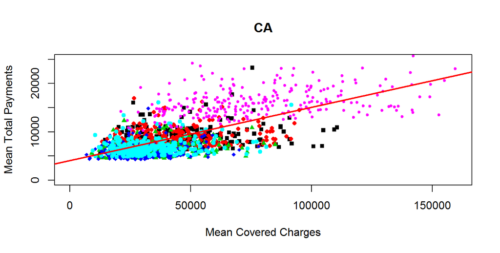

```r
lm.CA <- lm(Average.Total.Payments ~ Average.Covered.Charges, data=CA)
plot(x = CA$Average.Covered.Charges, y = CA$Average.Total.Payments, ylab = "Mean Total Payments", xlab = "Mean Covered Charges", main = "CA", col = CA$DRG.Definition, ylim = c(0,25000), xlim = c(0,160000), pch = c(15:20)[as.numeric(CA$DRG.Definition)], cex = 0.8)
abline(lm.CA, col = 2, lwd = 2)
```

**Thank You**